# Biorremediación de suelos

Mauricio Alessandrello

30-12-2023

## Procedimiento:

Se dispusieron pilas de 100 litros de suelo contaminado con hidrocarburos (concentración inicial: 36919 mg/kg) a las cuales se les realizaron los siguientes tratamientos:

- Atenuación natural: Agregado de agua y volteos cada 15 días.
- Bioestimulación: Igual que atenuación natural + agregado de fertilizante.
- Biosurfactante: Igual que bioestimulación + agregado de biosurfactante.
- Bioaumentación: Igual que bioestimulación + agregado de *Pseudomonas monteilli* P26

Cada mes se tomó una muestra de cada pila y se determinó la concentración de hidrocarburos y de bacterias degradadoras.

El ensayo se realizó entre el 6 de julio y el 22 de noviembre. Las temperaturas durante el transcurso del ensayo se obtuvieron del [registro del Servicio Meteorológico Nacional](https://www.smn.gob.ar/descarga-de-datos) (Fig. 1).

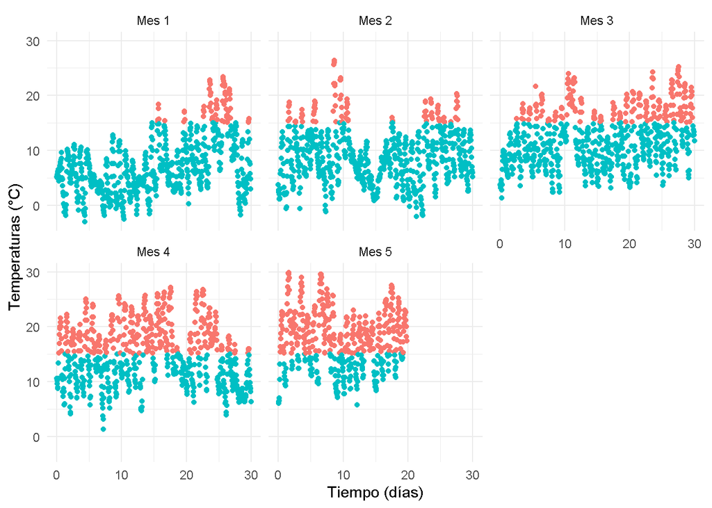

Fig.1: Temperaturas horarias para cada mes del ensayo. En naranja y celeste, las temperaturas mayores y menores a 15 °C respectivamente.

Nótese que durante los primeros dos meses, el 90% del tiempo la temperatura fue menor a 15.2 °C y la mitad del tiempo, menor a 7.6 °C, según se muestra con el siguiente código:

```r
temps <- temp_data2 %>% filter(días <60)%>% pull(TEMP)  #Se obtienen las temperaturas de los primeros 2 meses.

quantile(temps, seq(0, 1, 0.1))#Se calculan los deciles de las temperaturas de los primeros dos meses.
```

```
##    0%   10%   20%   30%   40%   50%   60%   70%   80%   90%  100%
## -3.00  1.60  3.58  4.80  6.20  7.60  8.80 10.50 12.60 15.20 26.40
```

## Resultados

En la figura 2 se observan las concentraciones de hidrocarburos y de bacterias degradadoras obtenidas para cada tratamiento durante el transcurso del ensayo.

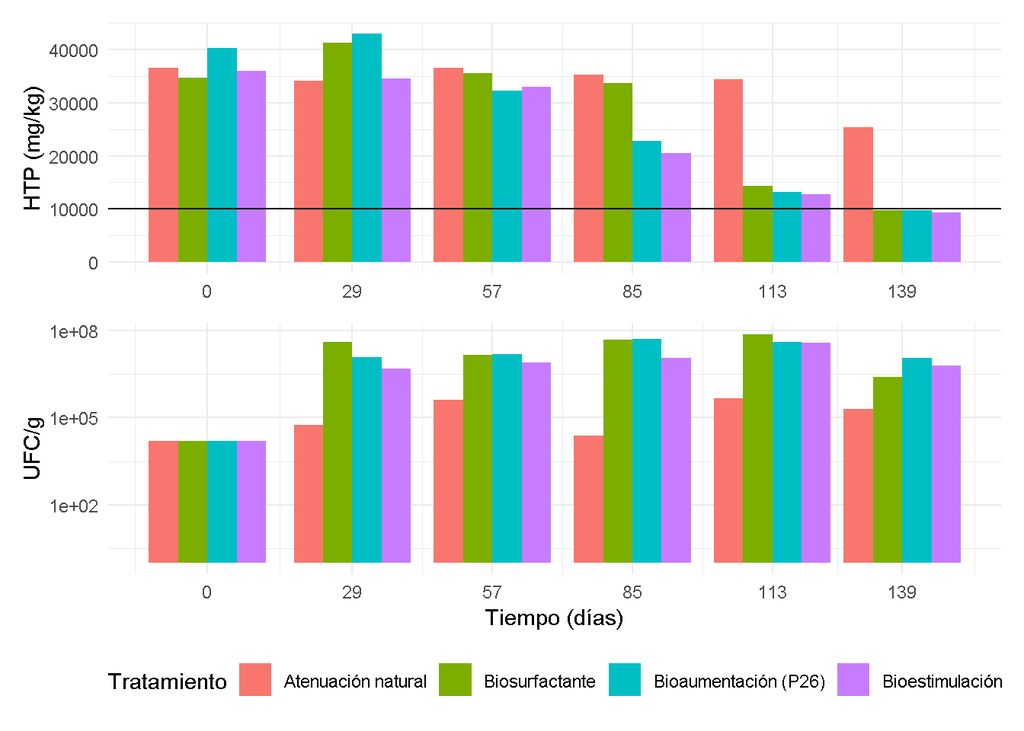

Fig. 2: Variación en la concentración de hidrocarburos y bacterias degradadoras durante el ensayo para los distintos tratamientos.

Se puede observar que a los 139 días la concentración de hidrocarburos para los tratamientos con fertilizante disminuyó por debajo de los 10000 mg/kg (línea horizontal). También puede observarse que durante los primeros dos meses la concentración de hidrocarburos no disminuyó, aún cuando se registró un incremento en la concentración de bacterias degradadoras.

## Análisis de datos

Para el análisis de datos, se realizan las siguientes suposiciones:

- Teniendo en cuenta que el efecto de la adición de fertilizante enmascara el efecto que pudiera tener la adición de biosurfactante o de P26, los tres ensayos a los que se les agregó fertilizante pueden considerarse réplicas de un mismo tratamiento. A este tratamiento lo llamaremos tratamiento con fertilizante o bioestimulación.
- El porcentaje de margen de error obtenido para los tratamientos con fertilizante será utilizado también para el tratamiento de atenuación natural, ante la imposibilidad de contar con réplicas de este tratamiento.

A continuación se presentan los cálculos realizados para la obtención de los resultados:

```r
#Se obtienen los valores iniciales de la concentración de HTP y se calcula su promedio
inicial <- deg_htp2 %>% filter(Tiempo == 0) %>% pull(HTP)

t0 <- mean(inicial)

#Se obtienen valores finales de la concentración de HTP para cada tratamiento


finalAN <- deg_htp2 %>% filter(Tiempo == 139 & Tratamiento == "AN") %>% pull(HTP)

finalBS <- deg_htp2 %>% filter(Tiempo == 139 & Tratamiento == "bs") %>% pull(HTP)

finalBioEst <- deg_htp2 %>% filter(Tiempo == 139 & Tratamiento == "bioest") %>% pull(HTP)

finalP26 <- deg_htp2 %>% filter(Tiempo == 139 & Tratamiento == "P26") %>% pull(HTP)


#Se crean variables para el cálculo de intervalos de confianza 95%

finalBIO <- c(finalBS, finalP26, finalBioEst) # Concentraciones finales de tratamientos biológicos, se consideran como réplicas los distintos tratamientos porque no evidenciaron diferencias.

avgBIO<- mean(finalBIO) # su promedio

N <- length(finalBIO) # número de réplicas

desvest <- sd(finalBIO) # su desviación estándar

moe <- qt(0.975, df = N-1) * desvest/sqrt(N) #margen de error de las concentraciones finales para el tratamiento con fertilizante usando una distribución t.

moe_perc <- moe/avgBIO*100 #margen de error en %

finalAN1 <- c(finalAN, finalAN + moe_perc*finalAN/100, finalAN - moe_perc*finalAN/100)# concentraciones finales del tratamiento AN. Se considera una variación de más/menos moe_perc obtenida para los tratamientos BIO

avgAN <- mean(finalAN1) # promedio de concentraciones finales del tratamiento atenuación natural.

desvestAN <- sd(finalAN1) # su desviación estándar

moeAN <- qt(0.975, df = N-1) * desvestAN/sqrt(N) # su margen de error


lim_supBIO <- avgBIO + moe #límite superior del intervalo de confianza 95% para los tratamientos con fertilizante

lim_infBIO <- avgBIO - moe # límite inferior del intervalo de confianza 95% para esos tratamientos

lim_supAN <- avgAN + moeAN # límite superior del intervalo de confianza 95% para el tratamiento de atenuación natural

lim_infAN <- avgAN - moeAN # límite inferior del intervalo de confianza 95% para el tratamiento de atenuación natural



#Datos adicionales

dBIO <- t0 - avgBIO #concentración de HTP degradado en tratamiento con fertilizante
dAN <- t0 - avgAN #concentración de HTP degradado en atenuación natural

dBIO_perc <- dBIO/t0 * 100 #lo mismo expresado en % para tratamiento con fertilizante
dAN_perc <- dAN/t0 * 100 #lo mismo expresado en % atenuación natural
```

Con los datos obtenidos se elabora la siguiente tabla con los resultados finales:

```
##                                        Bioestimulación Atenuación_natural
## Concentración final HTP (mg/kg)                   9605              25343
## Límite inferior 95% confianza (mg/kg)             8963              21138
## Límite superiror 95% confianza (mg/kg)           10246              29548
## Degradación de HTP (mg/kg)                       27314              11576
## Degradación de HTP (%)                              74                 31
```

Se realiza un test “t” y se obtiene un valor de p de 0.3%. Esto indica que hay un 0.3% de probabilidad de que la diferencia obtenida entre los promedios de las concentraciones finales de HTP para los tratamientos atenuación natural y bioestimulación sea producto del azar.

```r
t.test(finalAN1, finalBIO) # test t para la determinación del valor de p y del intervalo de confianza 95% de la diferencia entre las concentraciones finales de los tratamientos con fertilizante y atenuación natural.
```

```
##
##  Welch Two Sample t-test
##
## data:  finalAN1 and finalBIO
## t = 15.921, df = 2.0931, p-value = 0.003224
## alternative hypothesis: true difference in means is not equal to 0
## 95 percent confidence interval:
##  11661.11 19815.56
## sample estimates:
## mean of x mean of y
## 25343.000  9604.667
```

## Conclusiones

- Se evidencia crecimiento de bacterias degradadoras al mes de iniciado los tratamientos que contenían fertilizante, aún con temperaturas atmosféricas menores a 15 °C.
- A pesar del crecimiento bacteriano, durante los primeros dos meses de tratamiento no hubo disminución en la concentración de hidrocarburos. Esto sugiere que las bacterias utilizaron otra fuente de carbono para sustentar su reproducción y que el consumo de hidrocarburos recién comenzó una vez agotada esta otra fuente.
- La variación en el número de bacterias degradadoras de hidrocarburos es un mejor parámetro para determinar la actividad de la biopila que la variación en la concentración de hidrocarburos.
- En menos de 5 meses se alcanzó el objetivo de disminuir la concentración de hidrocarburos por debajo de los 10000 mg/kg.
- La adición de fertilizante, junto con volteos quincenales y el mantenimiento de la humedad es suficiente para un tratamiento eficiente.